# Risk Factor Analysis

## Outcome Variable

**Outcome Variable:** stunted

## Predictor Variables

**Intervention Variable:** gagebrth

**Adjustment Set:**

- arm
- sex
- W_mage
- meducyrs
- feducyrs
- hhwealth_quart
- W_mhtcm
- brthmon
- W_parity
- delta_W_mage
- delta_meducyrs
- delta_feducyrs
- delta_hhwealth_quart
- delta_W_mhtcm
- delta_brthmon
- delta_W_parity

## Stratifying Variables

The analysis was stratified on these variable(s):

- agecat
- studyid
- country

## Data Summary

| agecat | studyid | country | gagebrth | stunted | n_cell | n |
| --- | --- | --- | --- | --- | --- | --- |
| 6 months | ki1000108-CMC-V-BCS-2002 | INDIA | [273-287) | 0 | 109 | 347 |
| 6 months | ki1000108-CMC-V-BCS-2002 | INDIA | [273-287) | 1 | 38 | 347 |
| 6 months | ki1000108-CMC-V-BCS-2002 | INDIA | <259 | 0 | 26 | 347 |
| 6 months | ki1000108-CMC-V-BCS-2002 | INDIA | <259 | 1 | 21 | 347 |
| 6 months | ki1000108-CMC-V-BCS-2002 | INDIA | [259-273) | 0 | 51 | 347 |
| 6 months | ki1000108-CMC-V-BCS-2002 | INDIA | [259-273) | 1 | 23 | 347 |
| 6 months | ki1000108-CMC-V-BCS-2002 | INDIA | >=287 | 0 | 60 | 347 |
| 6 months | ki1000108-CMC-V-BCS-2002 | INDIA | >=287 | 1 | 19 | 347 |
| 24 months | ki1000108-CMC-V-BCS-2002 | INDIA | [273-287) | 0 | 43 | 350 |
| 24 months | ki1000108-CMC-V-BCS-2002 | INDIA | [273-287) | 1 | 105 | 350 |
| 24 months | ki1000108-CMC-V-BCS-2002 | INDIA | <259 | 0 | 11 | 350 |
| 24 months | ki1000108-CMC-V-BCS-2002 | INDIA | <259 | 1 | 36 | 350 |
| 24 months | ki1000108-CMC-V-BCS-2002 | INDIA | [259-273) | 0 | 16 | 350 |
| 24 months | ki1000108-CMC-V-BCS-2002 | INDIA | [259-273) | 1 | 59 | 350 |
| 24 months | ki1000108-CMC-V-BCS-2002 | INDIA | >=287 | 0 | 31 | 350 |
| 24 months | ki1000108-CMC-V-BCS-2002 | INDIA | >=287 | 1 | 49 | 350 |
| Birth | ki1000108-CMC-V-BCS-2002 | INDIA | [273-287) | 0 | 28 | 90 |
| Birth | ki1000108-CMC-V-BCS-2002 | INDIA | [273-287) | 1 | 7 | 90 |
| Birth | ki1000108-CMC-V-BCS-2002 | INDIA | <259 | 0 | 6 | 90 |
| Birth | ki1000108-CMC-V-BCS-2002 | INDIA | <259 | 1 | 1 | 90 |
| Birth | ki1000108-CMC-V-BCS-2002 | INDIA | [259-273) | 0 | 19 | 90 |
| Birth | ki1000108-CMC-V-BCS-2002 | INDIA | [259-273) | 1 | 3 | 90 |
| Birth | ki1000108-CMC-V-BCS-2002 | INDIA | >=287 | 0 | 21 | 90 |
| Birth | ki1000108-CMC-V-BCS-2002 | INDIA | >=287 | 1 | 5 | 90 |
| 6 months | ki1000108-IRC | INDIA | [273-287) | 0 | 131 | 388 |
| 6 months | ki1000108-IRC | INDIA | [273-287) | 1 | 34 | 388 |
| 6 months | ki1000108-IRC | INDIA | <259 | 0 | 21 | 388 |
| 6 months | ki1000108-IRC | INDIA | <259 | 1 | 19 | 388 |
| 6 months | ki1000108-IRC | INDIA | [259-273) | 0 | 70 | 388 |
| 6 months | ki1000108-IRC | INDIA | [259-273) | 1 | 21 | 388 |

[output cut: 230 more lines]

The following strata were considered:

- agecat: 24 months, studyid: ki1000108-CMC-V-BCS-2002, country: INDIA
- agecat: 24 months, studyid: ki1000108-IRC, country: INDIA
- agecat: 24 months, studyid: ki1017093c-NIH-Crypto, country: BANGLADESH
- agecat: 24 months, studyid: ki1066203-TanzaniaChild2, country: TANZANIA, UNITED REPUBLIC OF
- agecat: 24 months, studyid: ki1101329-Keneba, country: GAMBIA
- agecat: 24 months, studyid: ki1113344-GMS-Nepal, country: NEPAL
- agecat: 24 months, studyid: ki1119695-PROBIT, country: BELARUS
- agecat: 24 months, studyid: ki1135781-COHORTS, country: GUATEMALA
- agecat: 24 months, studyid: ki1135781-COHORTS, country: INDIA
- agecat: 24 months, studyid: ki1135781-COHORTS, country: PHILIPPINES
- agecat: 24 months, studyid: kiGH5241-JiVitA-3, country: BANGLADESH
- agecat: 6 months, studyid: ki1000108-CMC-V-BCS-2002, country: INDIA
- agecat: 6 months, studyid: ki1000108-IRC, country: INDIA
- agecat: 6 months, studyid: ki1000109-EE, country: PAKISTAN
- agecat: 6 months, studyid: ki1000304b-SAS-CompFeed, country: INDIA
- agecat: 6 months, studyid: ki1017093c-NIH-Crypto, country: BANGLADESH
- agecat: 6 months, studyid: ki1066203-TanzaniaChild2, country: TANZANIA, UNITED REPUBLIC OF
- agecat: 6 months, studyid: ki1101329-Keneba, country: GAMBIA
- agecat: 6 months, studyid: ki1113344-GMS-Nepal, country: NEPAL
- agecat: 6 months, studyid: ki1119695-PROBIT, country: BELARUS
- agecat: 6 months, studyid: ki1135781-COHORTS, country: GUATEMALA
- agecat: 6 months, studyid: ki1135781-COHORTS, country: INDIA
- agecat: 6 months, studyid: ki1135781-COHORTS, country: PHILIPPINES
- agecat: 6 months, studyid: kiGH5241-JiVitA-3, country: BANGLADESH
- agecat: Birth, studyid: ki1000108-CMC-V-BCS-2002, country: INDIA
- agecat: Birth, studyid: ki1000108-IRC, country: INDIA
- agecat: Birth, studyid: ki1000109-EE, country: PAKISTAN
- agecat: Birth, studyid: ki1000304b-SAS-CompFeed, country: INDIA
- agecat: Birth, studyid: ki1017093c-NIH-Crypto, country: BANGLADESH
- agecat: Birth, studyid: ki1101329-Keneba, country: GAMBIA
- agecat: Birth, studyid: ki1119695-PROBIT, country: BELARUS
- agecat: Birth, studyid: ki1135781-COHORTS, country: GUATEMALA
- agecat: Birth, studyid: ki1135781-COHORTS, country: INDIA
- agecat: Birth, studyid: ki1135781-COHORTS, country: PHILIPPINES
- agecat: Birth, studyid: kiGH5241-JiVitA-3, country: BANGLADESH

### Dropped Strata

Some strata were dropped due to rare outcomes:

- agecat: Birth, studyid: ki1000108-CMC-V-BCS-2002, country: INDIA
- agecat: 6 months, studyid: ki1000109-EE, country: PAKISTAN
- agecat: Birth, studyid: ki1000109-EE, country: PAKISTAN
- agecat: 6 months, studyid: ki1000304b-SAS-CompFeed, country: INDIA
- agecat: Birth, studyid: ki1000304b-SAS-CompFeed, country: INDIA
- agecat: Birth, studyid: ki1017093c-NIH-Crypto, country: BANGLADESH
- agecat: 6 months, studyid: ki1017093c-NIH-Crypto, country: BANGLADESH
- agecat: 24 months, studyid: ki1017093c-NIH-Crypto, country: BANGLADESH
- agecat: 24 months, studyid: ki1066203-TanzaniaChild2, country: TANZANIA, UNITED REPUBLIC OF
- agecat: Birth, studyid: ki1101329-Keneba, country: GAMBIA
- agecat: 6 months, studyid: ki1113344-GMS-Nepal, country: NEPAL
- agecat: 24 months, studyid: ki1113344-GMS-Nepal, country: NEPAL
- agecat: Birth, studyid: ki1119695-PROBIT, country: BELARUS

## Methods Detail

We’re interested in the causal parameters $E[Y_a]$ for all values of $a \in \mathcal{A}$. These parameters represent the mean outcome if, possibly contrary to fact, we intervened to set all units to have $A=a$. Under the randomization and positivity assumptions, these are identified by the statistical parameters $\psi_a=E_W[E_{Y|A,W}(Y|A=a,W)]$. In addition, we’re interested in the mean of $Y$, $E[Y]$ under no intervention (the observed mean). We will estimate these parameters by using SuperLearner to fit the relevant likelihood factors – $E_{Y|A,W}(Y|A=a,W)$ and $p(A=a|W)$, and then updating our likelihood fit using a joint TMLE.

For unadjusted analyses ($W=\{\}$), initial likelihoods were estimated using Lrnr_glm to estimate the simple $E(Y|A)$ and Lrnr_mean to estimate $p(A)$. For adjusted analyses, a small library containing Lrnr_glmnet, Lrnr_xgboost, and Lrnr_mean was used.

Having estimated these parameters, we will then use the delta method to estimate relative risks and attributable risks relative to a prespecified baseline level of $A$.

[output not shown]

[output not shown]

# Results Detail

## Results Plots

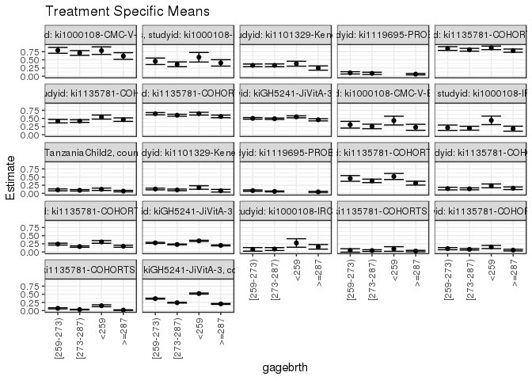

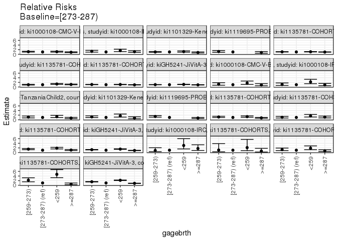

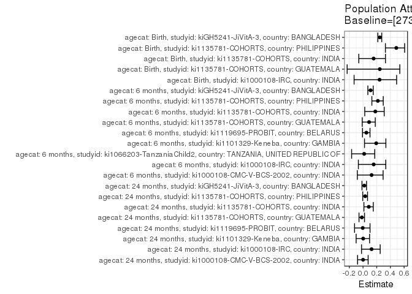

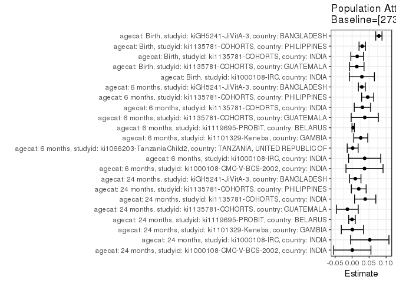

## Results Table

### Parameter: TSM

| agecat | studyid | country | intervention_level | baseline_level | estimate | ci_lower | ci_upper |
| --- | --- | --- | --- | --- | --- | --- | --- |
| Birth | ki1000108-IRC | INDIA | [273-287) | NA | 0.0904595 | 0.0462583 | 0.1346606 |
| Birth | ki1000108-IRC | INDIA | <259 | NA | 0.2753930 | 0.1454005 | 0.4053855 |
| Birth | ki1000108-IRC | INDIA | [259-273) | NA | 0.0798737 | 0.0246718 | 0.1350756 |
| Birth | ki1000108-IRC | INDIA | >=287 | NA | 0.1568610 | 0.0869016 | 0.2268205 |
| Birth | ki1135781-COHORTS | GUATEMALA | [273-287) | NA | 0.0428283 | 0.0169493 | 0.0687073 |
| Birth | ki1135781-COHORTS | GUATEMALA | <259 | NA | 0.0908897 | 0.0199471 | 0.1618323 |
| Birth | ki1135781-COHORTS | GUATEMALA | [259-273) | NA | 0.0458570 | -0.0059475 | 0.0976614 |
| Birth | ki1135781-COHORTS | GUATEMALA | >=287 | NA | 0.0272163 | 0.0039406 | 0.0504920 |
| Birth | ki1135781-COHORTS | INDIA | [273-287) | NA | 0.0810328 | 0.0578200 | 0.1042456 |
| Birth | ki1135781-COHORTS | INDIA | <259 | NA | 0.1514585 | 0.1033563 | 0.1995607 |
| Birth | ki1135781-COHORTS | INDIA | [259-273) | NA | 0.1016470 | 0.0681855 | 0.1351085 |
| Birth | ki1135781-COHORTS | INDIA | >=287 | NA | 0.0574830 | 0.0326713 | 0.0822947 |
| Birth | ki1135781-COHORTS | PHILIPPINES | [273-287) | NA | 0.0314355 | 0.0218526 | 0.0410185 |
| Birth | ki1135781-COHORTS | PHILIPPINES | <259 | NA | 0.1487337 | 0.1191711 | 0.1782962 |
| Birth | ki1135781-COHORTS | PHILIPPINES | [259-273) | NA | 0.0691048 | 0.0525004 | 0.0857091 |
| Birth | ki1135781-COHORTS | PHILIPPINES | >=287 | NA | 0.0152193 | 0.0056222 | 0.0248163 |
| Birth | kiGH5241-JiVitA-3 | BANGLADESH | [273-287) | NA | 0.2418581 | 0.2305575 | 0.2531587 |
| Birth | kiGH5241-JiVitA-3 | BANGLADESH | <259 | NA | 0.5217759 | 0.5051965 | 0.5383554 |
| Birth | kiGH5241-JiVitA-3 | BANGLADESH | [259-273) | NA | 0.3663820 | 0.3519415 | 0.3808224 |
| Birth | kiGH5241-JiVitA-3 | BANGLADESH | >=287 | NA | 0.2044122 | 0.1904977 | 0.2183268 |
| 6 months | ki1000108-CMC-V-BCS-2002 | INDIA | [273-287) | NA | 0.2546227 | 0.1849138 | 0.3243316 |
| 6 months | ki1000108-CMC-V-BCS-2002 | INDIA | <259 | NA | 0.4347570 | 0.2998011 | 0.5697128 |
| 6 months | ki1000108-CMC-V-BCS-2002 | INDIA | [259-273) | NA | 0.3075275 | 0.2042931 | 0.4107618 |
| 6 months | ki1000108-CMC-V-BCS-2002 | INDIA | >=287 | NA | 0.2283639 | 0.1360305 | 0.3206973 |
| 6 months | ki1000108-IRC | INDIA | [273-287) | NA | 0.2002213 | 0.1402624 | 0.2601802 |
| 6 months | ki1000108-IRC | INDIA | <259 | NA | 0.4411555 | 0.3103981 | 0.5719128 |
| 6 months | ki1000108-IRC | INDIA | [259-273) | NA | 0.2156920 | 0.1340355 | 0.2973484 |
| 6 months | ki1000108-IRC | INDIA | >=287 | NA | 0.1857587 | 0.1091755 | 0.2623419 |
| 6 months | ki1066203-TanzaniaChild2 | TANZANIA, UNITED REPUBLIC OF | [273-287) | NA | 0.0940143 | 0.0732265 | 0.1148021 |
| 6 months | ki1066203-TanzaniaChild2 | TANZANIA, UNITED REPUBLIC OF | <259 | NA | 0.1255688 | 0.0886287 | 0.1625088 |

[output cut: 56 more lines]

### Parameter: E(Y)

| agecat | studyid | country | intervention_level | baseline_level | estimate | ci_lower | ci_upper |
| --- | --- | --- | --- | --- | --- | --- | --- |
| Birth | ki1000108-IRC | INDIA | NA | NA | 0.1192412 | 0.0861307 | 0.1523517 |
| Birth | ki1135781-COHORTS | GUATEMALA | NA | NA | 0.0567261 | 0.0384591 | 0.0749931 |
| Birth | ki1135781-COHORTS | INDIA | NA | NA | 0.0959010 | 0.0798450 | 0.1119570 |
| Birth | ki1135781-COHORTS | PHILIPPINES | NA | NA | 0.0611773 | 0.0526341 | 0.0697204 |
| Birth | kiGH5241-JiVitA-3 | BANGLADESH | NA | NA | 0.3205490 | 0.3127517 | 0.3283463 |
| 6 months | ki1000108-CMC-V-BCS-2002 | INDIA | NA | NA | 0.2910663 | 0.2432023 | 0.3389303 |
| 6 months | ki1000108-IRC | INDIA | NA | NA | 0.2371134 | 0.1947393 | 0.2794875 |
| 6 months | ki1066203-TanzaniaChild2 | TANZANIA, UNITED REPUBLIC OF | NA | NA | 0.0956385 | 0.0824215 | 0.1088554 |
| 6 months | ki1101329-Keneba | GAMBIA | NA | NA | 0.1317322 | 0.1138432 | 0.1496211 |
| 6 months | ki1119695-PROBIT | BELARUS | NA | NA | 0.0626864 | 0.0488489 | 0.0765238 |
| 6 months | ki1135781-COHORTS | GUATEMALA | NA | NA | 0.4193548 | 0.3831093 | 0.4556004 |
| 6 months | ki1135781-COHORTS | INDIA | NA | NA | 0.1692073 | 0.1489117 | 0.1895030 |
| 6 months | ki1135781-COHORTS | PHILIPPINES | NA | NA | 0.2113882 | 0.1959475 | 0.2268289 |
| 6 months | kiGH5241-JiVitA-3 | BANGLADESH | NA | NA | 0.2583721 | 0.2489533 | 0.2677908 |
| 24 months | ki1000108-CMC-V-BCS-2002 | INDIA | NA | NA | 0.7114286 | 0.6638920 | 0.7589651 |
| 24 months | ki1000108-IRC | INDIA | NA | NA | 0.4153846 | 0.3664142 | 0.4643550 |
| 24 months | ki1101329-Keneba | GAMBIA | NA | NA | 0.3321799 | 0.3050172 | 0.3593427 |
| 24 months | ki1119695-PROBIT | BELARUS | NA | NA | 0.0852540 | 0.0554439 | 0.1150642 |
| 24 months | ki1135781-COHORTS | GUATEMALA | NA | NA | 0.7948718 | 0.7641122 | 0.8256314 |
| 24 months | ki1135781-COHORTS | INDIA | NA | NA | 0.4579511 | 0.4309402 | 0.4849620 |
| 24 months | ki1135781-COHORTS | PHILIPPINES | NA | NA | 0.6175743 | 0.5982239 | 0.6369246 |
| 24 months | kiGH5241-JiVitA-3 | BANGLADESH | NA | NA | 0.5005390 | 0.4858066 | 0.5152715 |

### Parameter: RR

| agecat | studyid | country | intervention_level | baseline_level | estimate | ci_lower | ci_upper |
| --- | --- | --- | --- | --- | --- | --- | --- |
| Birth | ki1000108-IRC | INDIA | [273-287) | [273-287) | 1.0000000 | 1.0000000 | 1.0000000 |
| Birth | ki1000108-IRC | INDIA | <259 | [273-287) | 3.0443802 | 1.5467992 | 5.9918901 |
| Birth | ki1000108-IRC | INDIA | [259-273) | [273-287) | 0.8829780 | 0.3788445 | 2.0579687 |
| Birth | ki1000108-IRC | INDIA | >=287 | [273-287) | 1.7340479 | 0.8995944 | 3.3425309 |
| Birth | ki1135781-COHORTS | GUATEMALA | [273-287) | [273-287) | 1.0000000 | 1.0000000 | 1.0000000 |
| Birth | ki1135781-COHORTS | GUATEMALA | <259 | [273-287) | 2.1221871 | 0.7927769 | 5.6808902 |
| Birth | ki1135781-COHORTS | GUATEMALA | [259-273) | [273-287) | 1.0707159 | 0.2972892 | 3.8562881 |
| Birth | ki1135781-COHORTS | GUATEMALA | >=287 | [273-287) | 0.6354748 | 0.2233998 | 1.8076481 |
| Birth | ki1135781-COHORTS | INDIA | [273-287) | [273-287) | 1.0000000 | 1.0000000 | 1.0000000 |
| Birth | ki1135781-COHORTS | INDIA | <259 | [273-287) | 1.8691019 | 1.2223908 | 2.8579583 |
| Birth | ki1135781-COHORTS | INDIA | [259-273) | [273-287) | 1.2543936 | 0.8142346 | 1.9324940 |
| Birth | ki1135781-COHORTS | INDIA | >=287 | [273-287) | 0.7093791 | 0.4239894 | 1.1868662 |
| Birth | ki1135781-COHORTS | PHILIPPINES | [273-287) | [273-287) | 1.0000000 | 1.0000000 | 1.0000000 |
| Birth | ki1135781-COHORTS | PHILIPPINES | <259 | [273-287) | 4.7313887 | 3.2954712 | 6.7929707 |
| Birth | ki1135781-COHORTS | PHILIPPINES | [259-273) | [273-287) | 2.1983020 | 1.4957744 | 3.2307891 |
| Birth | ki1135781-COHORTS | PHILIPPINES | >=287 | [273-287) | 0.4841422 | 0.2409363 | 0.9728449 |
| Birth | kiGH5241-JiVitA-3 | BANGLADESH | [273-287) | [273-287) | 1.0000000 | 1.0000000 | 1.0000000 |
| Birth | kiGH5241-JiVitA-3 | BANGLADESH | <259 | [273-287) | 2.1573637 | 2.0428631 | 2.2782819 |
| Birth | kiGH5241-JiVitA-3 | BANGLADESH | [259-273) | [273-287) | 1.5148632 | 1.4261507 | 1.6090940 |
| Birth | kiGH5241-JiVitA-3 | BANGLADESH | >=287 | [273-287) | 0.8451741 | 0.7809525 | 0.9146770 |
| 6 months | ki1000108-CMC-V-BCS-2002 | INDIA | [273-287) | [273-287) | 1.0000000 | 1.0000000 | 1.0000000 |
| 6 months | ki1000108-CMC-V-BCS-2002 | INDIA | <259 | [273-287) | 1.7074557 | 1.1295109 | 2.5811216 |
| 6 months | ki1000108-CMC-V-BCS-2002 | INDIA | [259-273) | [273-287) | 1.2077771 | 0.7834552 | 1.8619132 |
| 6 months | ki1000108-CMC-V-BCS-2002 | INDIA | >=287 | [273-287) | 0.8968715 | 0.5507614 | 1.4604845 |
| 6 months | ki1000108-IRC | INDIA | [273-287) | [273-287) | 1.0000000 | 1.0000000 | 1.0000000 |
| 6 months | ki1000108-IRC | INDIA | <259 | [273-287) | 2.2033396 | 1.4486923 | 3.3510951 |
| 6 months | ki1000108-IRC | INDIA | [259-273) | [273-287) | 1.0772680 | 0.6658742 | 1.7428312 |
| 6 months | ki1000108-IRC | INDIA | >=287 | [273-287) | 0.9277671 | 0.5577133 | 1.5433591 |
| 6 months | ki1066203-TanzaniaChild2 | TANZANIA, UNITED REPUBLIC OF | [273-287) | [273-287) | 1.0000000 | 1.0000000 | 1.0000000 |
| 6 months | ki1066203-TanzaniaChild2 | TANZANIA, UNITED REPUBLIC OF | <259 | [273-287) | 1.3356349 | 0.9267291 | 1.9249644 |

[output cut: 56 more lines]

### Parameter: PAR

| agecat | studyid | country | intervention_level | baseline_level | estimate | ci_lower | ci_upper |
| --- | --- | --- | --- | --- | --- | --- | --- |
| Birth | ki1000108-IRC | INDIA | [273-287) | NA | 0.0287817 | -0.0080600 | 0.0656235 |
| Birth | ki1135781-COHORTS | GUATEMALA | [273-287) | NA | 0.0138978 | -0.0072288 | 0.0350244 |
| Birth | ki1135781-COHORTS | INDIA | [273-287) | NA | 0.0148682 | -0.0037589 | 0.0334954 |
| Birth | ki1135781-COHORTS | PHILIPPINES | [273-287) | NA | 0.0297417 | 0.0203096 | 0.0391738 |
| Birth | kiGH5241-JiVitA-3 | BANGLADESH | [273-287) | NA | 0.0786909 | 0.0695071 | 0.0878746 |
| 6 months | ki1000108-CMC-V-BCS-2002 | INDIA | [273-287) | NA | 0.0364436 | -0.0180190 | 0.0909061 |
| 6 months | ki1000108-IRC | INDIA | [273-287) | NA | 0.0368921 | -0.0103659 | 0.0841502 |
| 6 months | ki1066203-TanzaniaChild2 | TANZANIA, UNITED REPUBLIC OF | [273-287) | NA | 0.0016242 | -0.0144524 | 0.0177007 |
| 6 months | ki1101329-Keneba | GAMBIA | [273-287) | NA | 0.0253853 | 0.0048407 | 0.0459299 |
| 6 months | ki1119695-PROBIT | BELARUS | [273-287) | NA | 0.0030543 | -0.0003591 | 0.0064676 |
| 6 months | ki1135781-COHORTS | GUATEMALA | [273-287) | NA | 0.0371797 | -0.0027189 | 0.0770784 |
| 6 months | ki1135781-COHORTS | INDIA | [273-287) | NA | 0.0303785 | 0.0063158 | 0.0544412 |
| 6 months | ki1135781-COHORTS | PHILIPPINES | [273-287) | NA | 0.0458079 | 0.0280399 | 0.0635759 |
| 6 months | kiGH5241-JiVitA-3 | BANGLADESH | [273-287) | NA | 0.0285677 | 0.0184166 | 0.0387189 |
| 24 months | ki1000108-CMC-V-BCS-2002 | INDIA | [273-287) | NA | 0.0005626 | -0.0542537 | 0.0553789 |
| 24 months | ki1000108-IRC | INDIA | [273-287) | NA | 0.0518828 | -0.0044864 | 0.1082521 |
| 24 months | ki1101329-Keneba | GAMBIA | [273-287) | NA | 0.0008465 | -0.0317667 | 0.0334597 |
| 24 months | ki1119695-PROBIT | BELARUS | [273-287) | NA | -0.0003589 | -0.0099964 | 0.0092785 |
| 24 months | ki1135781-COHORTS | GUATEMALA | [273-287) | NA | -0.0139303 | -0.0458845 | 0.0180238 |
| 24 months | ki1135781-COHORTS | INDIA | [273-287) | NA | 0.0384742 | 0.0072443 | 0.0697041 |
| 24 months | ki1135781-COHORTS | PHILIPPINES | [273-287) | NA | 0.0194791 | -0.0022703 | 0.0412285 |
| 24 months | kiGH5241-JiVitA-3 | BANGLADESH | [273-287) | NA | 0.0093545 | -0.0073509 | 0.0260600 |

### Parameter: PAF

| agecat | studyid | country | intervention_level | baseline_level | estimate | ci_lower | ci_upper |
| --- | --- | --- | --- | --- | --- | --- | --- |
| Birth | ki1000108-IRC | INDIA | [273-287) | NA | 0.2413740 | -0.1302248 | 0.4907974 |
| Birth | ki1135781-COHORTS | GUATEMALA | [273-287) | NA | 0.2449981 | -0.2316706 | 0.5371913 |
| Birth | ki1135781-COHORTS | INDIA | [273-287) | NA | 0.1550373 | -0.0619124 | 0.3276639 |
| Birth | ki1135781-COHORTS | PHILIPPINES | [273-287) | NA | 0.4861567 | 0.3267731 | 0.6078069 |
| Birth | kiGH5241-JiVitA-3 | BANGLADESH | [273-287) | NA | 0.2454878 | 0.2163958 | 0.2734998 |
| 6 months | ki1000108-CMC-V-BCS-2002 | INDIA | [273-287) | NA | 0.1252071 | -0.0828814 | 0.2933090 |
| 6 months | ki1000108-IRC | INDIA | [273-287) | NA | 0.1555885 | -0.0678426 | 0.3322698 |
| 6 months | ki1066203-TanzaniaChild2 | TANZANIA, UNITED REPUBLIC OF | [273-287) | NA | 0.0169824 | -0.1663552 | 0.1715014 |
| 6 months | ki1101329-Keneba | GAMBIA | [273-287) | NA | 0.1927037 | 0.0219184 | 0.3336678 |
| 6 months | ki1119695-PROBIT | BELARUS | [273-287) | NA | 0.0487230 | -0.0077537 | 0.1020346 |
| 6 months | ki1135781-COHORTS | GUATEMALA | [273-287) | NA | 0.0886594 | -0.0116671 | 0.1790365 |
| 6 months | ki1135781-COHORTS | INDIA | [273-287) | NA | 0.1795343 | 0.0251970 | 0.3094358 |
| 6 months | ki1135781-COHORTS | PHILIPPINES | [273-287) | NA | 0.2167004 | 0.1292622 | 0.2953582 |
| 6 months | kiGH5241-JiVitA-3 | BANGLADESH | [273-287) | NA | 0.1105682 | 0.0705800 | 0.1488359 |
| 24 months | ki1000108-CMC-V-BCS-2002 | INDIA | [273-287) | NA | 0.0007908 | -0.0793085 | 0.0749457 |
| 24 months | ki1000108-IRC | INDIA | [273-287) | NA | 0.1249031 | -0.0219848 | 0.2506791 |
| 24 months | ki1101329-Keneba | GAMBIA | [273-287) | NA | 0.0025482 | -0.1006262 | 0.0960510 |
| 24 months | ki1119695-PROBIT | BELARUS | [273-287) | NA | -0.0042102 | -0.1234876 | 0.1024039 |
| 24 months | ki1135781-COHORTS | GUATEMALA | [273-287) | NA | -0.0175253 | -0.0585907 | 0.0219472 |
| 24 months | ki1135781-COHORTS | INDIA | [273-287) | NA | 0.0840138 | 0.0132269 | 0.1497228 |
| 24 months | ki1135781-COHORTS | PHILIPPINES | [273-287) | NA | 0.0315413 | -0.0043331 | 0.0661343 |
| 24 months | kiGH5241-JiVitA-3 | BANGLADESH | [273-287) | NA | 0.0186889 | -0.0152060 | 0.0514522 |